Unit 14 · Practicing Dummy Variable Specifications

# Build the Model from the Hypothesis

Dummy variables, reference categories, interactions, and structural changes. Fourteen exercises that start from a picture and a question, and end with a single coefficient that answers it.

Section one

## How to use this handout

The conventions, the four-step routine, and the one rule that answers most of the questions.

Before you start

Every picture is a set of conditional means.

Points and lines stand for group means or conditional means, not fitted estimates with standard errors. **The picture suggests a contrast; it does not establish statistical significance or causality.** A real test needs case-level data and a standard error appropriate to the design. The numbers are illustrative.

Four steps for every question.

1. **Define the indicators** and name the reference (omitted) group.
2. **Write the regression equation.** Assume an error term in every model.
3. **State the null hypothesis** as a restriction on a coefficient, such as *β*<sub>2</sub> = 0.
4. **Interpret each relevant coefficient** as a specific difference between two points in the picture.

The one rule behind almost every answer.

Software tests every coefficient against zero. A coefficient on a dummy is **the gap between that category and the omitted category, measured where every other predictor equals zero**. So if you want a contrast tested for you, choose two things:

- the **reference category**, so the comparison is against the group you care about; and
- the **zero point** of any continuous variable (by centering), so the gap is measured where you care about it: a cutoff, an intervention date, a benchmark.

How to get coefficients from a picture.

Write the equation once for each cell, setting each dummy to its 0/1 value. The reference cell gives you the intercept. Every other cell adds exactly one new coefficient, so you can solve for each one by subtraction.

Coding conventions.

- Every indicator is written *d*<sub>name</sub> and equals 1 when the name is true.
- The column headed 1 is the intercept. *Y* is the illustrated cell mean unless stated otherwise.
- Design matrices often display *complementary* indicators side by side (for example *d*<sub>treat</sub> and *d*<sub>control</sub>) so you can see both reference choices. **Never enter a complete set of complementary indicators together with an intercept.** Columns left out of the model are shown in grey.
- Rows are observation *types*. Real data would have many rows of each type, which is where the standard errors come from.

Work the questions before reading the solutions.

Each solution repeats the figure and question, then gives a short answer, the reasoning, a design matrix, the model, a coefficient table, and a common mistake.

Section two

## Questions

Fourteen designs, roughly in order of difficulty. Each links to its solution.

### 1. Two means: three t-test designs

Three designs that each compare two means, and the regression that reproduces each t-test.

### 1A. One sample versus a benchmark

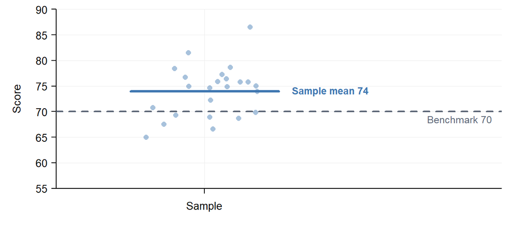

Solution →

### 1B. Two independent samples

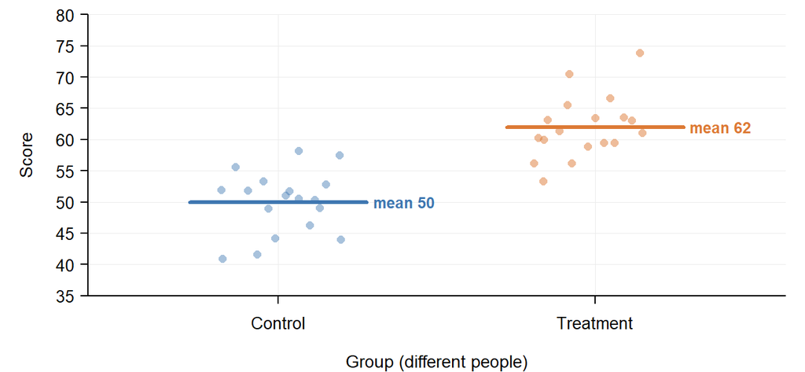

Solution →

### 1C. Paired samples

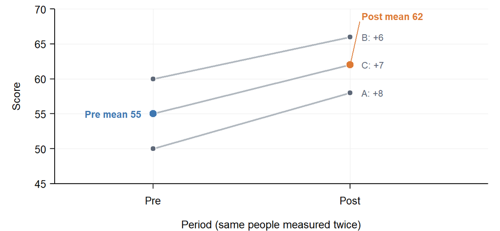

Solution →

### 2. Three categories, two reference choices

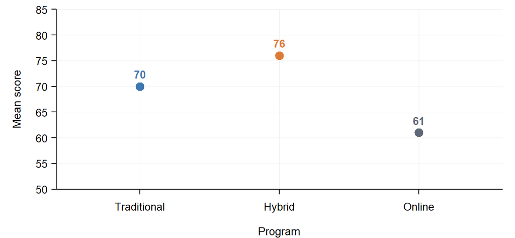

Solution →

### 3. Parallel lines: a common slope

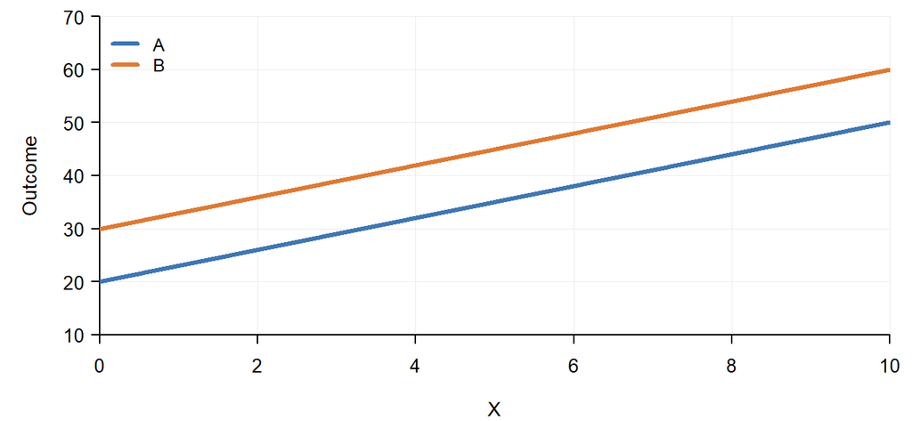

Solution →

### 4. Nonparallel lines: intercept and slope interactions

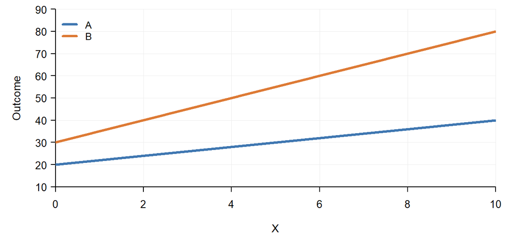

Solution →

### 5. A 2 × 2 program-by-setting design

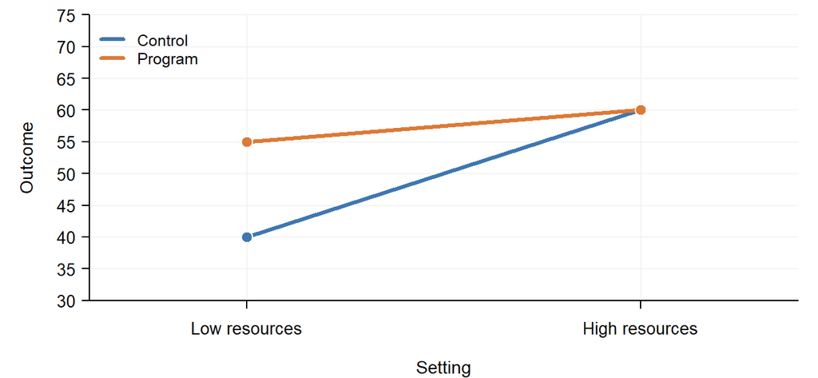

Solution →

### 6. Pre/post with a comparison group

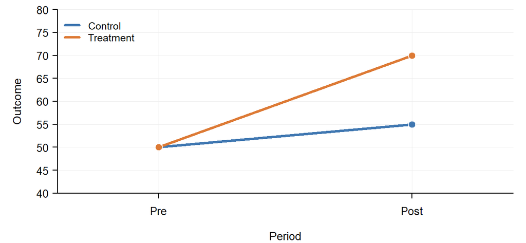

Solution →

### 7. Cumulative doses

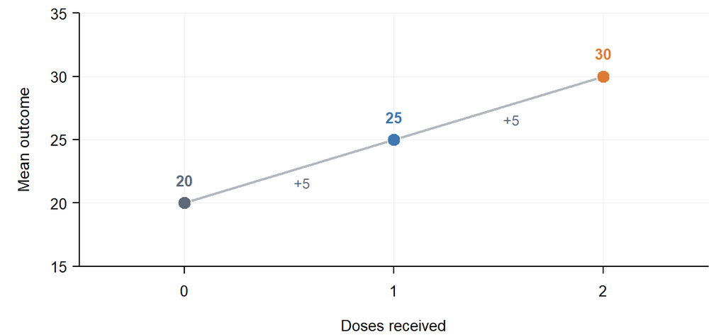

Solution →

### 8. Interrupted time series

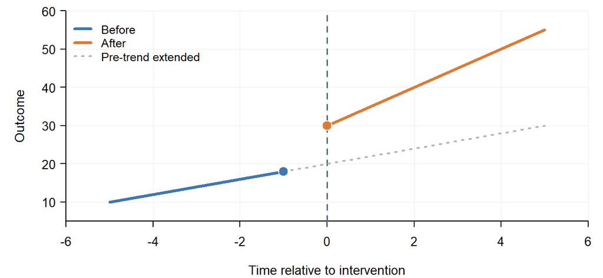

Solution →

### 9. Regression discontinuity at a cutoff

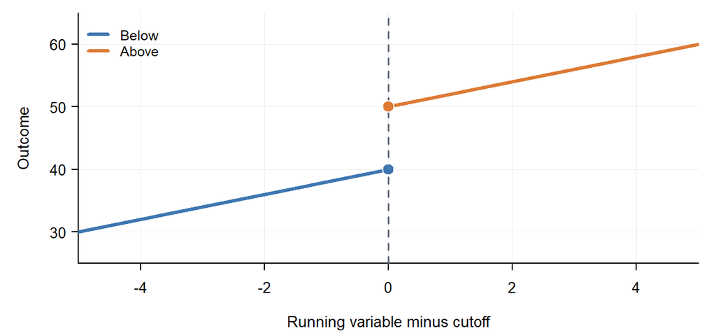

Solution →

### 10. A special pile of observations at predictor zero

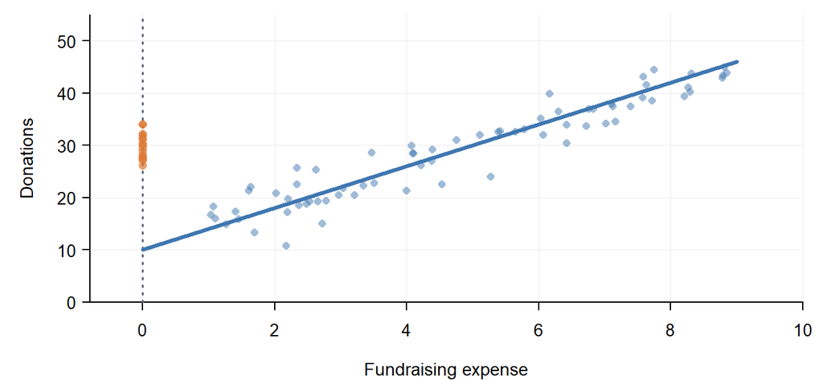

Solution →

### 11. Zero group and size-specific slopes

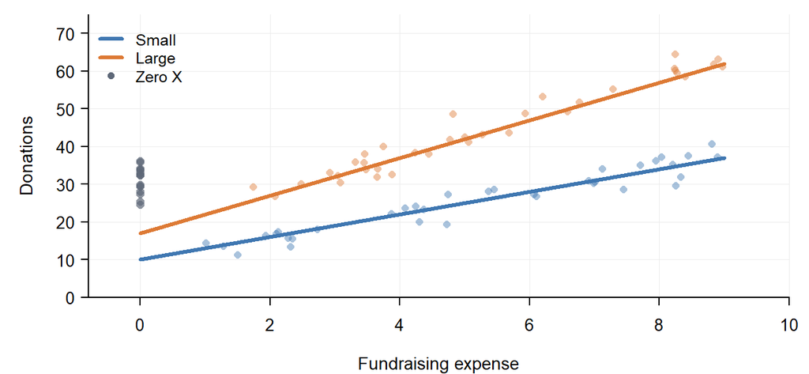

Solution →

### 12. A single outlying year

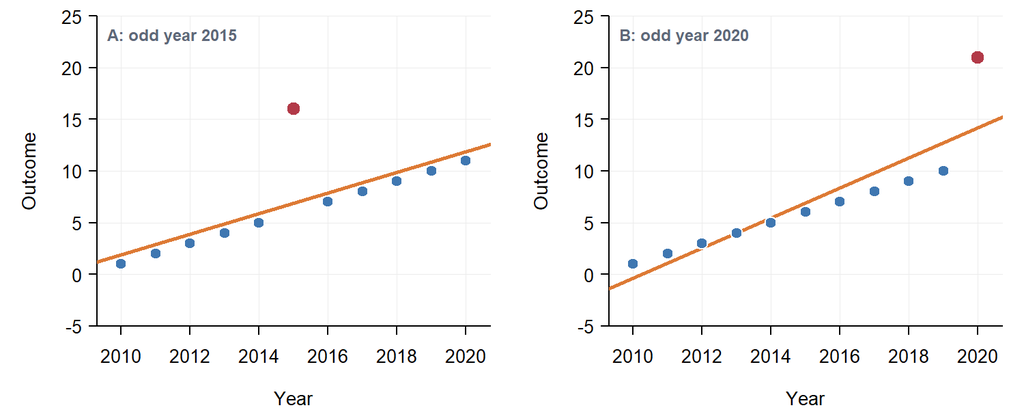

Solution →

### 13. COVID anomalies and a later regime

Exercise 12 with three odd years instead of one, and a question about what comes after them.

### 13A. Flat before, flat after

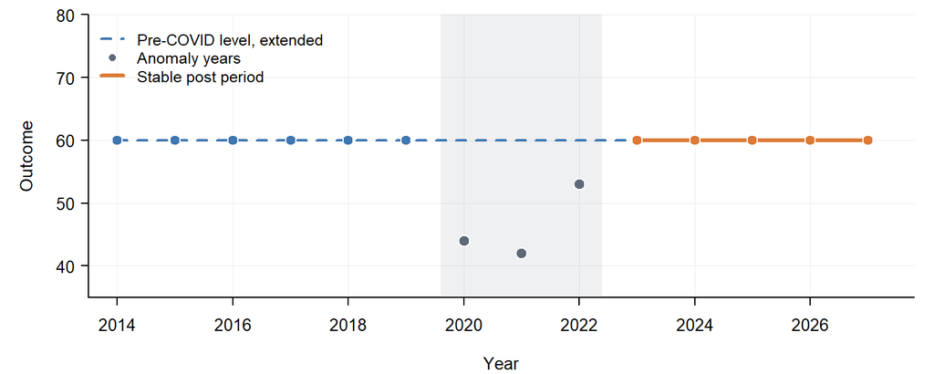

Solution →

### 13B. Add a trend

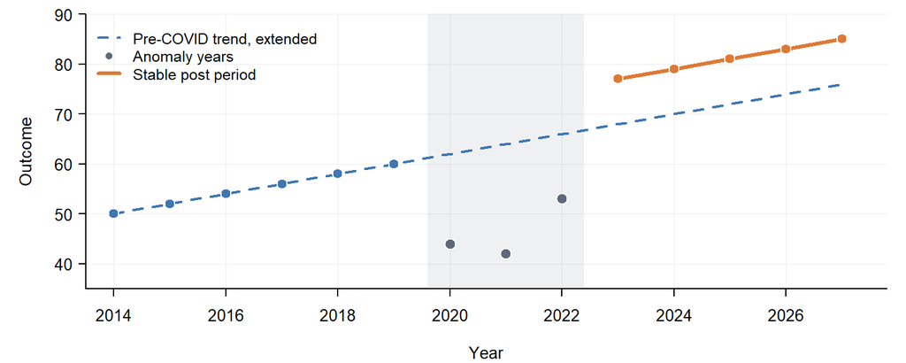

Solution →

### 13C. What if the post-COVID slope changed?

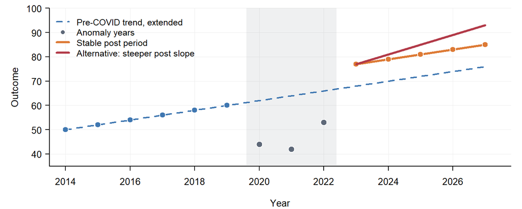

Solution →

### 14. Reverse-engineer the coding

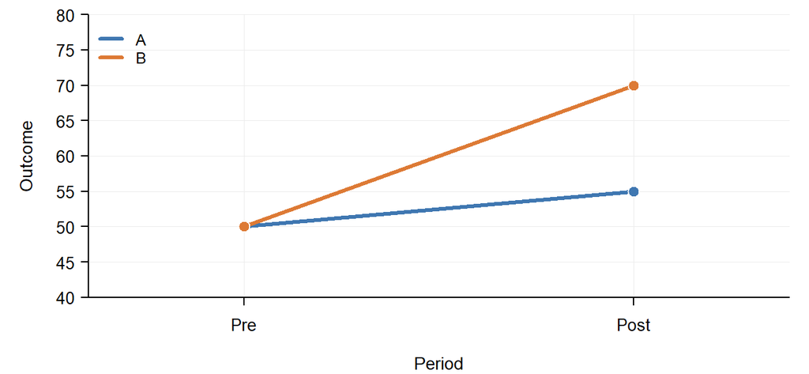

Solution →

Section three

## Solutions and common mistakes

Short answer first, then the reasoning, the design matrix, the model, what each coefficient tests, and the mistake to avoid.

### 1A. One sample versus a benchmark

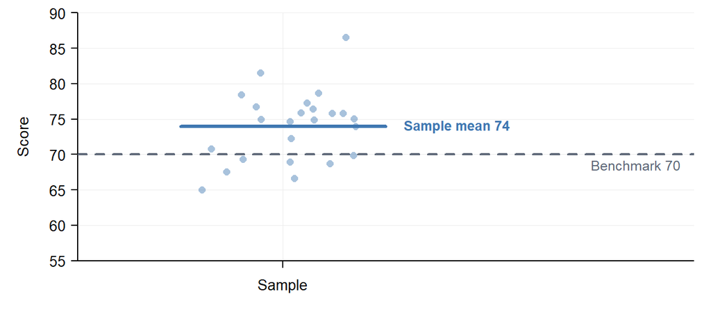

Short answer

Subtract the benchmark from the outcome, *Y*<sub>c</sub> = *Y* − 70, and regress it on a constant alone. The intercept is the sample mean minus the benchmark (74 − 70 = 4), and testing *β*<sub>0</sub> = 0 is exactly the one-sample t-test of *μ* = 70. A group dummy cannot help: there is only one group, so the dummy would be a column of ones that duplicates the intercept.

#### Why this works

A regression with nothing but a constant estimates the mean of the outcome, and its standard error is *s*/√*n*, the same standard error the one-sample t-test uses. The only problem is that software tests the intercept against *zero*, and nobody doubts that the mean score is above zero. Shifting the outcome by 70 moves the benchmark to zero, so the default test becomes the test you want.

An equivalent route is to regress raw *Y* on a constant (*β*<sub>0</sub> = 74) and ask for the linear-hypothesis test *β*<sub>0</sub> = 70. The t-statistic is identical. Recentering simply makes the right test the default one.

#### Design matrix

| Observation type | *Y* | *Y*<sub>c</sub> | 1 |
| --- | --- | --- | --- |
| Sample mean | 74 | 4 | 1 |

In real data each person supplies one row with their own *Y*<sub>c</sub>.

#### Model

*Y*<sub>c</sub> = *β*<sub>0</sub> + *ε*

| Coefficient | Value | Testing it equals zero asks… |
| --- | --- | --- |
| *β*<sub>0</sub> | 4 | Does the population mean equal the benchmark of 70? |

Common mistakes

- **Creating *d*<sub>above</sub> = I(*Y* > 70) as a predictor.** It is built from the outcome itself, so it only splits cases into above and below the benchmark. It says nothing about whether the *mean* equals 70.
- **Regressing raw *Y* on a constant and reading the default p-value.** That tests whether the mean is zero, not whether it is 70.

← Back to question

### 1B. Two independent samples

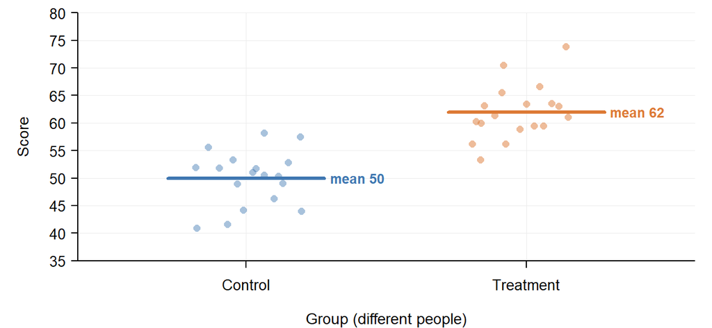

Short answer

Use *Y* = *β*<sub>0</sub> + *β*<sub>1</sub>*d*<sub>treat</sub> + *ε*. The intercept is the control mean (50) and *β*<sub>1</sub> = 12 is treatment minus control, so testing *β*<sub>1</sub> = 0 is the two-sample t-test. Omitting treatment instead gives (62, −12): the same test, the same |t|, with the sign reversed.

#### Why this works

With one dummy and a constant, the constant takes care of the omitted group and the dummy measures how far the other group sits from it. Write the equation for each row:

- Control (*d*<sub>treat</sub> = 0): *Y* = *β*<sub>0</sub> = 50
- Treatment (*d*<sub>treat</sub> = 1): *Y* = *β*<sub>0</sub> + *β*<sub>1</sub> = 62, so *β*<sub>1</sub> = 12

Ordinary OLS standard errors pool the two groups’ variances, so this matches the equal-variance (Student) t-test. For the Welch test, ask for heteroskedasticity-robust standard errors.

#### Design matrix

Both indicators are shown so you can see both reference choices. Include only **one** alongside the intercept.

| Observation type | *Y* | 1 | *d*<sub>treat</sub> | *d*<sub>control</sub> |
| --- | --- | --- | --- | --- |
| Control | 50 | 1 | 0 | 1 |
| Treatment | 62 | 1 | 1 | 0 |

#### Models

Model A (control reference): *Y* = *β*<sub>0</sub> + *β*<sub>1</sub>*d*<sub>treat</sub> + *ε*

Model B (treatment reference): *Y* = *γ*<sub>0</sub> + *γ*<sub>1</sub>*d*<sub>control</sub> + *ε*

| Coefficient | Value | Testing it equals zero asks… |
| --- | --- | --- |
| Model A · control reference |  |  |
| *β*<sub>0</sub> | 50 | Is the control mean zero? (descriptive only) |
| *β*<sub>1</sub> | 12 | Does the treatment mean equal the control mean? |
| Model B · treatment reference |  |  |
| *γ*<sub>0</sub> | 62 | Is the treatment mean zero? (descriptive only) |
| *γ*<sub>1</sub> | −12 | Does the control mean equal the treatment mean? |

Common mistakes

- **Entering 1, *d*<sub>treat</sub>, and *d*<sub>control</sub> together.** Because *d*<sub>treat</sub> + *d*<sub>control</sub> = 1 on every row, the two dummies add up to the intercept column (perfect collinearity), and the coefficients cannot be identified.
- **Calling *γ*<sub>1</sub> “treatment minus control.”** In Model B it is control minus treatment. The named category is always compared *to* the omitted one.

← Back to question

### 1C. Paired samples

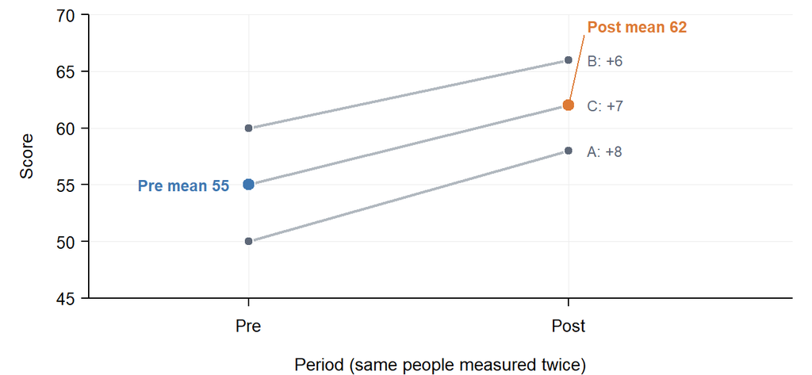

Short answer

All three models estimate the same thing: the average within-person change, (8 + 6 + 7)/3 = 7, with the same standard error. The independent-samples version gets the same 7 but a much larger standard error, because it leaves the stable differences *between* people in the error term. Pairing makes each person their own control.

#### (a) Difference-score regression

Compute each person’s change, Δ<sub>A</sub> = 8, Δ<sub>B</sub> = 6, Δ<sub>C</sub> = 7, and regress it on a constant:

Δ<sub>*i*</sub> = *γ*<sub>0</sub> + *u*<sub>*i*</sub>, *γ̂*<sub>0</sub> = 7

This is 1A again, applied to the differences. Testing *γ*<sub>0</sub> = 0 is the paired t-test.

#### (b) Long format with ID dummies

*Y*<sub>*it*</sub> = *α*<sub>A</sub>*d*<sub>A</sub> + *α*<sub>B</sub>*d*<sub>B</sub> + *α*<sub>C</sub>*d*<sub>C</sub> + *β**d*<sub>post</sub> + *ε*<sub>*it*</sub>

There is **no common intercept**: all three ID dummies are included, and together they do the intercept’s job. Each person gets their own baseline, and *β̂* = 7 is the common within-person change.

Why are the fitted intercepts 50.5, 59.5, 55 rather than the observed pre scores 50, 60, 55? The model forces everyone to share one change of 7, but the actual changes are 8, 6, and 7. Each *α̂*<sub>*i*</sub> therefore lands at the person’s own average minus half the common change. For A, 54 − 3.5 = 50.5. The leftover ±0.5 residuals are the only error the model sees.

#### (c) Person-specific intercepts

*Y*<sub>*it*</sub> = *α*<sub>*i*</sub> + *β**d*<sub>post</sub> + *ε*<sub>*it*</sub>, *i* ∈ {A, B, C}

This is the same model as (b) in shorter notation. *α*<sub>*i*</sub> stands for the three ID columns; it is *not* a single common intercept. This is the one-way fixed-effects model you will see again in panel data.

#### Why the standard errors differ

People differ a lot in *level* (pre scores of 50, 60, 55) but very little in *change* (8, 6, 7). The independent-samples test compares the two columns of scores, so all of that level variation counts as noise. The paired test compares each person with themselves, so it disappears.

| Analysis | Estimate | What goes into the standard error |
| --- | --- | --- |
| Paired / ID dummies | 7 | SD of the changes = 1, so SE = 1/√3 ≈ 0.58, *t* ≈ 12 |
| Independent samples | 7 | Pooled SD of levels ≈ 4.5, so SE ≈ 3.7, *t* ≈ 1.9 |

#### Design matrix

| Observation type | *Y* | *d*<sub>A</sub> | *d*<sub>B</sub> | *d*<sub>C</sub> | *d*<sub>pre</sub> | *d*<sub>post</sub> |
| --- | --- | --- | --- | --- | --- | --- |
| A, pre | 50 | 1 | 0 | 0 | 1 | 0 |
| A, post | 58 | 1 | 0 | 0 | 0 | 1 |
| B, pre | 60 | 0 | 1 | 0 | 1 | 0 |
| B, post | 66 | 0 | 1 | 0 | 0 | 1 |
| C, pre | 55 | 0 | 0 | 1 | 1 | 0 |
| C, post | 62 | 0 | 0 | 1 | 0 | 1 |

| Coefficient | Value | Testing it equals zero asks… |
| --- | --- | --- |
| ID dummies / *α*<sub>*i*</sub> |  |  |
| *α*<sub>A</sub>, *α*<sub>B</sub>, *α*<sub>C</sub> | 50.5, 59.5, 55 | Is this person’s fitted baseline zero? (descriptive only) |
| *β* | 7 | Is the average within-person change zero? |
| Difference scores |  |  |
| *γ*<sub>0</sub> | 7 | Is the mean of the paired differences zero? |

Common mistakes

- **Fitting `Y ~ d_post` and calling it a paired t-test.** The coefficient is still 7 in balanced data, but the standard error treats the six rows as independent and ignores the matched IDs.
- **Adding a common intercept to *d*<sub>A</sub>, *d*<sub>B</sub>, *d*<sub>C</sub>.** The ID dummies sum to one on every row, so this is perfectly collinear. The same goes for entering both *d*<sub>pre</sub> and *d*<sub>post</sub> alongside all the ID dummies.

← Back to question

### 2. Three categories, two reference choices

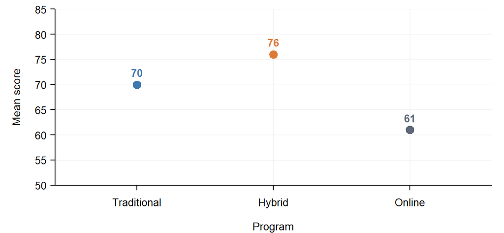

Short answer

Omit the category that every requested contrast shares. Model A omits Traditional and gives (70, 6, −9). Model B omits Online and gives (61, 9, 15). The two models fit the data identically; they just put p-values on different comparisons.

#### Why this works

Three groups allow three pairwise comparisons, but a model with an intercept has room for only two dummy coefficients. Whichever category you omit becomes the comparison point for *both* of them. The third comparison is still available as a difference of coefficients, but it needs a separate linear-combination test. In Model A, Hybrid versus Online is *β*<sub>1</sub> − *β*<sub>2</sub> = 6 − (−9) = 15, which Model B reports directly as *γ*<sub>2</sub>.

- Model A, Traditional row: *β*<sub>0</sub> = 70. Hybrid: 70 + *β*<sub>1</sub> = 76. Online: 70 + *β*<sub>2</sub> = 61.
- Model B, Online row: *γ*<sub>0</sub> = 61. Traditional: 61 + *γ*<sub>1</sub> = 70. Hybrid: 61 + *γ*<sub>2</sub> = 76.

#### Design matrix

| Observation type | *Y* | 1 | *d*<sub>traditional</sub> | *d*<sub>hybrid</sub> | *d*<sub>online</sub> |
| --- | --- | --- | --- | --- | --- |
| Traditional | 70 | 1 | 1 | 0 | 0 |
| Hybrid | 76 | 1 | 0 | 1 | 0 |
| Online | 61 | 1 | 0 | 0 | 1 |

Each model uses the constant and **two** of the three indicators.

#### Models

Model A: *Y* = *β*<sub>0</sub> + *β*<sub>1</sub>*d*<sub>hybrid</sub> + *β*<sub>2</sub>*d*<sub>online</sub> + *ε*

Model B: *Y* = *γ*<sub>0</sub> + *γ*<sub>1</sub>*d*<sub>traditional</sub> + *γ*<sub>2</sub>*d*<sub>hybrid</sub> + *ε*

| Coefficient | Value | Testing it equals zero asks… |
| --- | --- | --- |
| Model A · Traditional reference |  |  |
| *β*<sub>0</sub> | 70 | Is the Traditional mean zero? (descriptive only) |
| *β*<sub>1</sub> | 6 | Does Hybrid equal Traditional? |
| *β*<sub>2</sub> | −9 | Does Online equal Traditional? |
| Model B · Online reference |  |  |
| *γ*<sub>0</sub> | 61 | Is the Online mean zero? (descriptive only) |
| *γ*<sub>1</sub> | 9 | Does Traditional equal Online? |
| *γ*<sub>2</sub> | 15 | Does Hybrid equal Online? |

Common mistakes

- **Omitting Hybrid for Model A.** Both coefficients would then compare with Hybrid, and Online versus Traditional would be a difference of two coefficients rather than one.
- **Including all three indicators with the constant.** They sum to the intercept column, so the model is not identified.

← Back to question

### 3. Parallel lines: a common slope

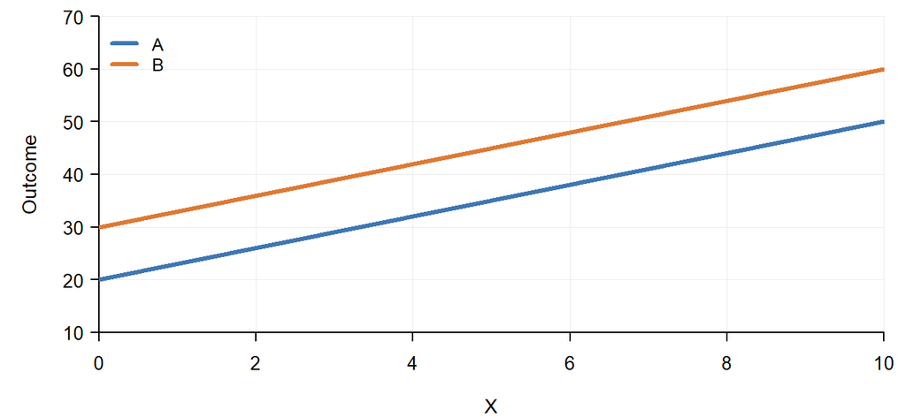

Short answer

*Y* = *β*<sub>0</sub> + *β*<sub>1</sub>*X* + *β*<sub>2</sub>*d*<sub>B</sub> + *ε* gives (20, 3, 10). *β*<sub>1</sub> is the common slope and *β*<sub>2</sub> is the vertical gap between the lines. You have **imposed** equal slopes, not tested them: with no *X*·*d*<sub>B</sub> term, the model cannot draw anything but parallel lines.

#### Why this works

Write the line for each group:

- A (*d*<sub>B</sub> = 0): *Y* = *β*<sub>0</sub> + *β*<sub>1</sub>*X*
- B (*d*<sub>B</sub> = 1): *Y* = (*β*<sub>0</sub> + *β*<sub>2</sub>) + *β*<sub>1</sub>*X*

A dummy on its own moves a line up or down. It cannot tilt it. Because both lines share *β*<sub>1</sub>, the gap *β*<sub>2</sub> = 10 is the same at every value of *X*. That is the one situation in which “the group difference” has a single answer. To *check* whether the lines really are parallel, add the interaction and test it (exercise 4).

#### Design matrix

| Observation type | *Y* | 1 | *X* | *d*<sub>A</sub> | *d*<sub>B</sub> |
| --- | --- | --- | --- | --- | --- |
| A, *X* = 0 | 20 | 1 | 0 | 1 | 0 |
| A, *X* = 5 | 35 | 1 | 5 | 1 | 0 |
| B, *X* = 0 | 30 | 1 | 0 | 0 | 1 |
| B, *X* = 5 | 45 | 1 | 5 | 0 | 1 |

#### Models

A reference: *Y* = *β*<sub>0</sub> + *β*<sub>1</sub>*X* + *β*<sub>2</sub>*d*<sub>B</sub> + *ε*

B reference: *Y* = *γ*<sub>0</sub> + *γ*<sub>1</sub>*X* + *γ*<sub>2</sub>*d*<sub>A</sub> + *ε*

| Coefficient | Value | Testing it equals zero asks… |
| --- | --- | --- |
| A reference |  |  |
| *β*<sub>0</sub> | 20 | Is A’s mean at *X* = 0 zero? (descriptive only) |
| *β*<sub>1</sub> | 3 | Is the common slope zero? |
| *β*<sub>2</sub> | 10 | Are A and B equal at the same *X*? |
| B reference |  |  |
| *γ*<sub>0</sub> | 30 | Is B’s mean at *X* = 0 zero? (descriptive only) |
| *γ*<sub>1</sub> | 3 | Is the common slope zero? |
| *γ*<sub>2</sub> | −10 | Are A and B equal at the same *X*? |

Common mistakes

- **Adding *X*·*d*<sub>B</sub> but still calling the *d*<sub>B</sub> coefficient “the gap.”** Once the slopes can differ, the gap is *β*<sub>2</sub> + *β*<sub>3</sub>*X*, and *β*<sub>2</sub> alone is the gap only at *X* = 0.
- **Using a dummy to test a slope difference.** A dummy alone can only shift intercepts.

← Back to question

### 4. Nonparallel lines: intercept and slope interactions

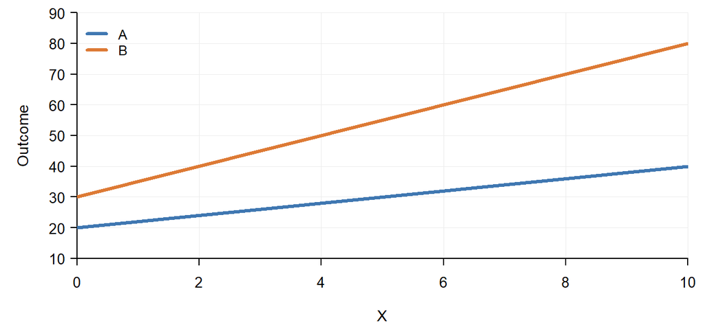

Short answer

*Y* = *β*<sub>0</sub> + *β*<sub>1</sub>*X* + *β*<sub>2</sub>*d*<sub>B</sub> + *β*<sub>3</sub>(*X*·*d*<sub>B</sub>) + *ε* gives (20, 2, 10, 3): A’s slope, the intercept gap, and the slope gap are each one coefficient. B’s slope is *β*<sub>1</sub> + *β*<sub>3</sub> = 5, a sum. To make it a single coefficient, make B the reference by using *d*<sub>A</sub> and *X*·*d*<sub>A</sub> instead. Then *γ*<sub>1</sub> = 5.

#### Why this works

Write each group’s line and match it to the picture:

- A: *Y* = *β*<sub>0</sub> + *β*<sub>1</sub>*X* = 20 + 2*X*
- B: *Y* = (*β*<sub>0</sub> + *β*<sub>2</sub>) + (*β*<sub>1</sub> + *β*<sub>3</sub>)*X* = 30 + 5*X*

The main-effect dummy shifts the intercept and the interaction shifts the slope. Every coefficient describes the reference group (A) or B’s *difference* from it. In particular, *β*<sub>1</sub> is not “the effect of *X*”; it is the effect of *X* **for A**.

Also note what the intercept gap means now. *β*<sub>2</sub> = 10 is the gap at *X* = 0 only. At *X* = 5 the gap is 10 + 3·5 = 25. If *X* = 0 is outside your data or not meaningful, center *X* at a value you care about, and *β*<sub>2</sub> becomes the gap there.

#### Design matrix

The interaction columns are products of *X* and the named dummy. Use the B pair **or** the A pair, depending on the reference.

| Observation type | *Y* | 1 | *X* | *d*<sub>A</sub> | *d*<sub>B</sub> | *X**d*<sub>A</sub> | *X**d*<sub>B</sub> |
| --- | --- | --- | --- | --- | --- | --- | --- |
| A, *X* = 0 | 20 | 1 | 0 | 1 | 0 | 0 | 0 |
| A, *X* = 5 | 30 | 1 | 5 | 1 | 0 | 5 | 0 |
| B, *X* = 0 | 30 | 1 | 0 | 0 | 1 | 0 | 0 |
| B, *X* = 5 | 55 | 1 | 5 | 0 | 1 | 0 | 5 |

#### Models

A reference: *Y* = *β*<sub>0</sub> + *β*<sub>1</sub>*X* + *β*<sub>2</sub>*d*<sub>B</sub> + *β*<sub>3</sub>(*X**d*<sub>B</sub>) + *ε*

B reference: *Y* = *γ*<sub>0</sub> + *γ*<sub>1</sub>*X* + *γ*<sub>2</sub>*d*<sub>A</sub> + *γ*<sub>3</sub>(*X**d*<sub>A</sub>) + *ε*

| Coefficient | Value | Testing it equals zero asks… |
| --- | --- | --- |
| A reference |  |  |
| *β*<sub>0</sub> | 20 | Is A’s intercept zero? (descriptive only) |
| *β*<sub>1</sub> | 2 | Is A’s slope zero? |
| *β*<sub>2</sub> | 10 | Are A and B equal at *X* = 0? |
| *β*<sub>3</sub> | 3 | Do A and B have the same slope? |
| B reference |  |  |
| *γ*<sub>0</sub> | 30 | Is B’s intercept zero? (descriptive only) |
| *γ*<sub>1</sub> | 5 | Is B’s slope zero? |
| *γ*<sub>2</sub> | −10 | Are A and B equal at *X* = 0? |
| *γ*<sub>3</sub> | −3 | Do A and B have the same slope? |

Common mistakes

- **Leaving out the interaction and reading *d*<sub>B</sub> as a slope difference.** Without *X**d*<sub>B</sub> the model forces the slopes to match (exercise 3).
- **Reading *β*<sub>3</sub> = 3 as B’s slope.** It is the *difference* between B’s slope and A’s. B’s slope is *β*<sub>1</sub> + *β*<sub>3</sub>.

← Back to question

### 5. A 2 × 2 program-by-setting design

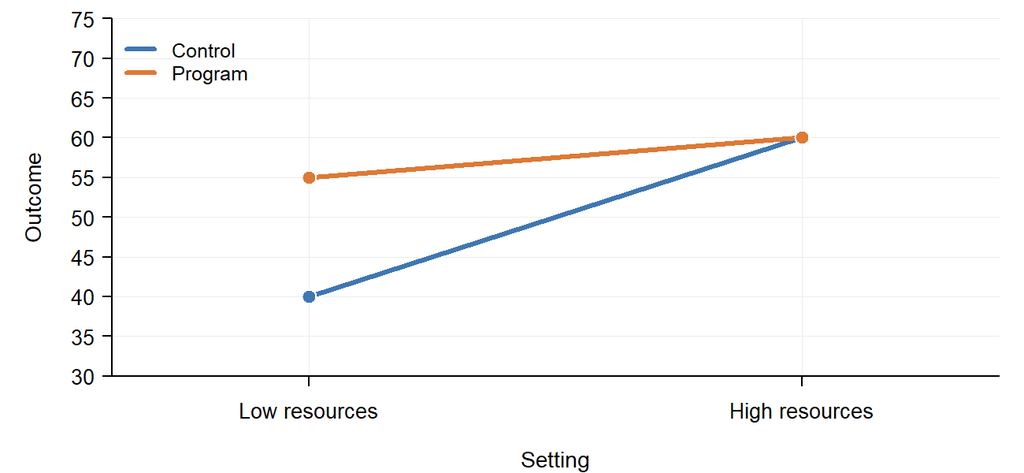

Short answer

With low settings as the reference (use *d*<sub>high</sub>), the model gives (40, 15, 20, −15). The program effect in low settings is *β*<sub>1</sub> = 15, the difference in effects is *β*<sub>3</sub> = −15, and the high-setting effect is the sum *β*<sub>1</sub> + *β*<sub>3</sub> = 0. To test the high-setting effect as one coefficient, make **high** the reference by using *d*<sub>low</sub>. Then *γ*<sub>1</sub> = 0.

#### Why this works

The key idea: **a main effect in an interacted model is the effect where the other dummy equals zero**, which is in the reference category of the other factor. So the program coefficient is the program effect in whichever setting you omitted.

- Control, low: *β*<sub>0</sub> = 40
- Program, low: *β*<sub>0</sub> + *β*<sub>1</sub> = 55 → *β*<sub>1</sub> = 15
- Control, high: *β*<sub>0</sub> + *β*<sub>2</sub> = 60 → *β*<sub>2</sub> = 20
- Program, high: *β*<sub>0</sub> + *β*<sub>1</sub> + *β*<sub>2</sub> + *β*<sub>3</sub> = 60 → *β*<sub>3</sub> = −15

The interaction is the gap between what you’d expect if program and setting simply added up (40 + 15 + 20 = 75) and what you actually see (60). Here the program closes the resource gap in low settings and does nothing where resources are already high. The interaction test is the same in both codings; only its sign flips.

#### Design matrix

| Observation type | *Y* | 1 | *d*<sub>program</sub> | *d*<sub>low</sub> | *d*<sub>high</sub> | *d*<sub>program</sub>*d*<sub>low</sub> | *d*<sub>program</sub>*d*<sub>high</sub> |
| --- | --- | --- | --- | --- | --- | --- | --- |
| Control, low | 40 | 1 | 0 | 1 | 0 | 0 | 0 |
| Program, low | 55 | 1 | 1 | 1 | 0 | 1 | 0 |
| Control, high | 60 | 1 | 0 | 0 | 1 | 0 | 0 |
| Program, high | 60 | 1 | 1 | 0 | 1 | 0 | 1 |

#### Models

Low reference: *Y* = *β*<sub>0</sub> + *β*<sub>1</sub>*d*<sub>program</sub> + *β*<sub>2</sub>*d*<sub>high</sub> + *β*<sub>3</sub>(*d*<sub>program</sub>*d*<sub>high</sub>) + *ε*

High reference: *Y* = *γ*<sub>0</sub> + *γ*<sub>1</sub>*d*<sub>program</sub> + *γ*<sub>2</sub>*d*<sub>low</sub> + *γ*<sub>3</sub>(*d*<sub>program</sub>*d*<sub>low</sub>) + *ε*

| Coefficient | Value | Testing it equals zero asks… |
| --- | --- | --- |
| Low-setting reference |  |  |
| *β*<sub>0</sub> | 40 | Is the control/low mean zero? (descriptive only) |
| *β*<sub>1</sub> | 15 | Is there a program effect in low settings? |
| *β*<sub>2</sub> | 20 | Do high and low settings differ among controls? |
| *β*<sub>3</sub> | −15 | Is the program effect the same in both settings? |
| High-setting reference |  |  |
| *γ*<sub>0</sub> | 60 | Is the control/high mean zero? (descriptive only) |
| *γ*<sub>1</sub> | 0 | Is there a program effect in high settings? |
| *γ*<sub>2</sub> | −20 | Do low and high settings differ among controls? |
| *γ*<sub>3</sub> | 15 | Is the program effect the same in both settings? |

Common mistakes

- **Coding *d*<sub>high</sub> but reading the program coefficient as the high-setting effect.** Because *d*<sub>high</sub> = 0 in low settings, the program main effect describes *low* settings.
- **Calling *β*<sub>1</sub> “the average program effect.”** In an interacted model there is no single program effect. There is one per setting.
- **Entering *d*<sub>low</sub> and *d*<sub>high</sub> together with an intercept.** That is perfectly collinear.

← Back to question

### 6. Pre/post with a comparison group

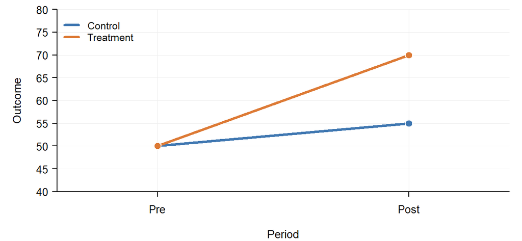

Short answer

With control/pre as the reference, *Y* = *β*<sub>0</sub> + *β*<sub>1</sub>*d*<sub>treat</sub> + *β*<sub>2</sub>*d*<sub>post</sub> + *β*<sub>3</sub>(*d*<sub>treat</sub>*d*<sub>post</sub>) + *ε* gives (50, 0, 5, 15). *β*<sub>1</sub> is the baseline gap, *β*<sub>2</sub> is the control group’s change, and the **interaction *β*<sub>3</sub>** is the difference in changes. This is the difference-in-differences estimator.

#### Why this works

This is exercise 5 with “setting” replaced by “time.” Solve cell by cell:

- Control, pre: *β*<sub>0</sub> = 50
- Treatment, pre: *β*<sub>0</sub> + *β*<sub>1</sub> = 50 → *β*<sub>1</sub> = 0
- Control, post: *β*<sub>0</sub> + *β*<sub>2</sub> = 55 → *β*<sub>2</sub> = 5
- Treatment, post: *β*<sub>0</sub> + *β*<sub>1</sub> + *β*<sub>2</sub> + *β*<sub>3</sub> = 70 → *β*<sub>3</sub> = 15

So *β*<sub>3</sub> = (70 − 50) − (55 − 50) = 20 − 5 = 15. The control group’s change (5) is the counterfactual: what would have happened to the treatment group without the program. *β*<sub>0</sub> + *β*<sub>1</sub> + *β*<sub>2</sub> = 55 is the treatment group’s expected post score under that counterfactual, and *β*<sub>3</sub> is how far the observed 70 sits above it. Reading *β*<sub>3</sub> as a program effect requires the **parallel-trends** assumption: without the program, both groups would have changed by the same amount.

Changing the reference changes what the main effects mean. Flipping *one* reference (group or period) flips the sign of the interaction; flipping both leaves it unchanged.

#### Design matrix

| Observation type | *Y* | 1 | *d*<sub>control</sub> | *d*<sub>treat</sub> | *d*<sub>pre</sub> | *d*<sub>post</sub> | *d*<sub>treat</sub>*d*<sub>post</sub> |
| --- | --- | --- | --- | --- | --- | --- | --- |
| Control, pre | 50 | 1 | 1 | 0 | 1 | 0 | 0 |
| Treatment, pre | 50 | 1 | 0 | 1 | 1 | 0 | 0 |
| Control, post | 55 | 1 | 1 | 0 | 0 | 1 | 0 |
| Treatment, post | 70 | 1 | 0 | 1 | 0 | 1 | 1 |

| Coefficient | Value | Testing it equals zero asks… |
| --- | --- | --- |
| Control/pre reference |  |  |
| *β*<sub>0</sub> | 50 | Is the control pre mean zero? (descriptive only) |
| *β*<sub>1</sub> | 0 | Are treatment and control equal at baseline? |
| *β*<sub>2</sub> | 5 | Did the control group change from pre to post? |
| *β*<sub>3</sub> | 15 | Did the treatment group change by the same amount as control? |

Common mistakes

- **Using the post-period group gap (70 − 55 = 15) as the estimator.** It matches here only because the baseline gap happens to be zero. In general it mixes the program effect with any pre-existing difference.
- **Using the treatment group’s own change (20).** It fails to subtract the change of 5 that would have happened anyway.
- **Adding *d*<sub>control</sub> beside *d*<sub>treat</sub>, or *d*<sub>pre</sub> beside *d*<sub>post</sub>, with an intercept.** Both are collinear.

← Back to question

### 7. Cumulative doses

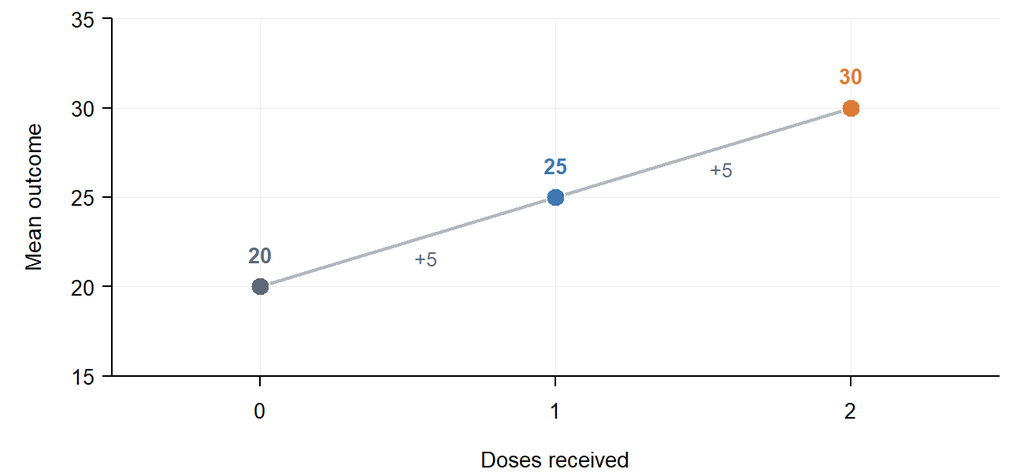

Short answer

Define *d*<sub>dose1</sub> = 1 if a person received **at least** one dose and *d*<sub>dose2</sub> = 1 if they received at least two. The model gives (20, 5, 5): *β*<sub>1</sub> is the gain from the first dose and *β*<sub>2</sub> is the *additional* gain from the second. Exact-group indicators give (20, 5, 10) instead, comparing each group with zero doses.

#### Why this works

A two-dose person has *both* cumulative indicators switched on, so their predicted mean is *β*<sub>0</sub> + *β*<sub>1</sub> + *β*<sub>2</sub>. A one-dose person has *β*<sub>0</sub> + *β*<sub>1</sub>. The difference between them is *β*<sub>2</sub> alone, the step from one dose to two.

With exact-group indicators, a two-dose person has only *d*<sub>two</sub> switched on, so *α*<sub>2</sub> is the whole distance from zero doses. The second increment is still there, but only as *α*<sub>2</sub> − *α*<sub>1</sub> = 5.

Both codings fit the same three means; they differ only in which contrasts get a p-value. Cumulative coding also lets you test whether each dose adds the same amount (*β*<sub>1</sub> = *β*<sub>2</sub>). That is exactly the assumption a linear dose term *β*·doses would impose without testing. The same stacking idea reappears in exercises 8 and 13, where a post-period dummy is added on top of a trend.

#### Design matrix

The exact-group pair (*d*<sub>one</sub>, *d*<sub>two</sub>) and the cumulative pair (*d*<sub>dose1</sub>, *d*<sub>dose2</sub>) encode **different contrasts**. Use one pair, not both.

| Observation type | *Y* | 1 | *d*<sub>none</sub> | *d*<sub>one</sub> | *d*<sub>two</sub> | *d*<sub>dose1</sub> | *d*<sub>dose2</sub> |
| --- | --- | --- | --- | --- | --- | --- | --- |
| Zero doses | 20 | 1 | 1 | 0 | 0 | 0 | 0 |
| One dose | 25 | 1 | 0 | 1 | 0 | 1 | 0 |
| Two doses | 30 | 1 | 0 | 0 | 1 | 1 | 1 |

#### Models

Exact groups: *Y* = *α*<sub>0</sub> + *α*<sub>1</sub>*d*<sub>one</sub> + *α*<sub>2</sub>*d*<sub>two</sub> + *ε*

Cumulative: *Y* = *β*<sub>0</sub> + *β*<sub>1</sub>*d*<sub>dose1</sub> + *β*<sub>2</sub>*d*<sub>dose2</sub> + *ε*

| Coefficient | Value | Testing it equals zero asks… |
| --- | --- | --- |
| Exact groups |  |  |
| *α*<sub>0</sub> | 20 | Is the zero-dose mean zero? (descriptive only) |
| *α*<sub>1</sub> | 5 | Does one dose differ from none? |
| *α*<sub>2</sub> | 10 | Do two doses differ from none? |
| Cumulative |  |  |
| *β*<sub>0</sub> | 20 | Is the zero-dose mean zero? (descriptive only) |
| *β*<sub>1</sub> | 5 | Does the first dose add anything? |
| *β*<sub>2</sub> | 5 | Does the second dose add anything beyond the first? |

Common mistakes

- **Calling *α*<sub>2</sub> = 10 “the effect of the second dose.”** It is the total difference between two doses and none.
- **Coding *d*<sub>dose1</sub> = 1 only for people with exactly one dose.** That turns it back into an exact-group indicator, and it no longer measures cumulative exposure.
- **Reading the dose coefficients causally without asking how dosage was assigned.** People who choose a second dose may differ from those who do not.

← Back to question

### 8. Interrupted time series

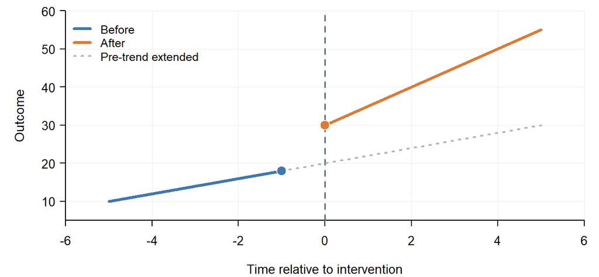

Short answer

*Y* = *β*<sub>0</sub> + *β*<sub>1</sub>*t* + *β*<sub>2</sub>*d*<sub>post</sub> + *β*<sub>3</sub>*t*<sub>after</sub> + *ε*, with *t*<sub>after</sub> = *t*·*d*<sub>post</sub>, gives (20, 2, 10, 3). *β*<sub>2</sub> is the immediate jump, *β*<sub>3</sub> is the change in slope, and the post slope is *β*<sub>1</sub> + *β*<sub>3</sub> = 5. A kink with no jump means *β*<sub>2</sub> = 0. You can test that, or impose it by dropping *d*<sub>post</sub>.

#### Why this works

This is exercise 4 with time as *X* and before/after as the groups:

- Before: *Y* = *β*<sub>0</sub> + *β*<sub>1</sub>*t* = 20 + 2*t*
- After: *Y* = (*β*<sub>0</sub> + *β*<sub>2</sub>) + (*β*<sub>1</sub> + *β*<sub>3</sub>)*t* = 30 + 5*t*

Because *t*<sub>after</sub> = 0 at the first post period, the two lines differ by exactly *β*<sub>2</sub> at *t* = 0. That is the gap between the observed post level (30) and where the old trend would have been (20). **Centering time at the interruption is what makes the dummy coefficient mean “jump at the interruption.”** Note that *β*<sub>0</sub> = 20 is not an observed point; it is the pre-trend extrapolated to *t* = 0, the counterfactual level.

#### Design matrix

| Observation type | *Y* | 1 | *t* | *d*<sub>pre</sub> | *d*<sub>post</sub> | *t*<sub>after</sub> |
| --- | --- | --- | --- | --- | --- | --- |
| Before, *t* = −2 | 16 | 1 | −2 | 1 | 0 | 0 |
| Before, *t* = −1 | 18 | 1 | −1 | 1 | 0 | 0 |
| First post, *t* = 0 | 30 | 1 | 0 | 0 | 1 | 0 |
| Post, *t* = 1 | 35 | 1 | 1 | 0 | 1 | 1 |

| Coefficient | Value | Testing it equals zero asks… |
| --- | --- | --- |
| Pre-period reference |  |  |
| *β*<sub>0</sub> | 20 | Is the extrapolated pre level at *t* = 0 zero? (descriptive only) |
| *β*<sub>1</sub> | 2 | Was there a pre-intervention trend? |
| *β*<sub>2</sub> | 10 | Was there an immediate level change at the interruption? |
| *β*<sub>3</sub> | 3 | Did the slope change after the interruption? |

Common mistakes

- **Using only *d*<sub>post</sub> to test a slope change.** A dummy on its own gives a jump with parallel lines.
- **Starting the post-period counter at 1.** If *t*<sub>after</sub> = 1 in the first post period, the post line becomes (*β*<sub>0</sub> + *β*<sub>2</sub> + *β*<sub>3</sub>) + (*β*<sub>1</sub> + *β*<sub>3</sub>)*t*. The jump at *t* = 0 is then *β*<sub>2</sub> + *β*<sub>3</sub>, and *β*<sub>2</sub> alone (here 7, not 10) is a gap one period *before* the interruption.
- **Adding *d*<sub>pre</sub> alongside *d*<sub>post</sub> and the intercept.** Use one or the other.

← Back to question

### 9. Regression discontinuity at a cutoff

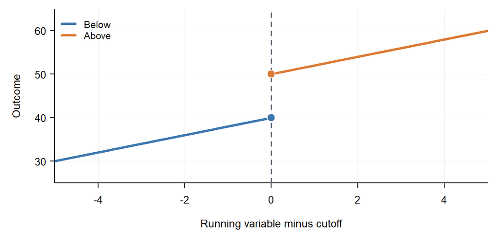

Short answer

Let *x*<sub>c</sub> = *X* − 50 and *d*<sub>above</sub> = I(*X* ≥ 50). Then *Y* = *β*<sub>0</sub> + *β*<sub>1</sub>*x*<sub>c</sub> + *β*<sub>2</sub>*d*<sub>above</sub> + *ε* gives (40, 2, 10), and *β*<sub>2</sub> is the program effect: the jump at the cutoff. The treatment shifts the intercept and leaves the slope alone, so both sides share *β*<sub>1</sub>. With parallel lines, centering does **not** change the jump estimate. It makes the intercept meaningful, and it becomes essential as soon as you add a slope interaction to check the common-slope assumption.

#### Why this works

This is exercise 3, parallel lines, with the running variable as *X* and eligibility as the group. It is also exercise 8 without the slope change:

- Below: *Y* = *β*<sub>0</sub> + *β*<sub>1</sub>*x*<sub>c</sub> = 40 + 2*x*<sub>c</sub>
- Above: *Y* = (*β*<sub>0</sub> + *β*<sub>2</sub>) + *β*<sub>1</sub>*x*<sub>c</sub> = 50 + 2*x*<sub>c</sub>

The logic of the design is that units just below and just above the cutoff are comparable, so the only thing that changes as *X* crosses 50 is eligibility. The running variable’s relationship with the outcome carries straight through the cutoff, and the program shows up as a **shift in the intercept** at that point. That is *β*<sub>2</sub>.

The value 40 is a **left-hand limit**: where the untreated line arrives at the cutoff. Nobody at *X* = 50 is untreated, so it is never observed directly. It is the counterfactual for the units just above the line.

#### Does centering matter?

Not for the jump, in this model. With raw *X* the lines are −60 + 2*X* and −50 + 2*X*, so the dummy coefficient is still 10. Parallel lines are the same distance apart everywhere, as in exercise 3. Centering changes only the intercept: −60 is the outcome extrapolated to *X* = 0, while 40 is the untreated level at the cutoff.

Centering *does* matter the moment you let the slopes differ, for example to check the common-slope assumption by adding *x*<sub>c</sub>*d*<sub>above</sub> and testing whether its coefficient is zero. The dummy then measures the gap where the running variable equals zero. With *x*<sub>c</sub> that is still the cutoff. With raw *X* it is *X* = 0, far outside the data, where even a slope difference of 0.2 would move the dummy coefficient by 50 × 0.2 = 10. If the check shows clearly different slopes, the straight-line model near the cutoff deserves a closer look before you trust the jump.

#### Design matrix

| Observation type | *Y* | 1 | *X* | *x*<sub>c</sub> | *d*<sub>below</sub> | *d*<sub>above</sub> |
| --- | --- | --- | --- | --- | --- | --- |
| Below, *X* = 48 | 36 | 1 | 48 | −2 | 1 | 0 |
| Below, *X* = 49 | 38 | 1 | 49 | −1 | 1 | 0 |
| Cutoff, *X* = 50 | 50 | 1 | 50 | 0 | 0 | 1 |
| Above, *X* = 51 | 52 | 1 | 51 | 1 | 0 | 1 |

Raw *X* is shown only to explain centering. Including both *X* and *x*<sub>c</sub> with an intercept is collinear. Using *d*<sub>below</sub> instead of *d*<sub>above</sub> reverses the sign of the jump.

| Coefficient | Value | Testing it equals zero asks… |
| --- | --- | --- |
| Below-cutoff reference |  |  |
| *β*<sub>0</sub> | 40 | Is the left-hand limit at the cutoff zero? (descriptive only) |
| *β*<sub>1</sub> | 2 | Is the outcome related to the running variable, on either side? |
| *β*<sub>2</sub> | 10 | Is there a jump at the cutoff, the program effect? |

Common mistakes

- **Leaving out the running variable.** `Y ~ d_above` compares the average outcome above the cutoff with the average below it. Because the outcome rises with *X* anyway, that difference mixes the jump with the slope. With data from *X* = 40 to 60 it reports 31, three times the true jump of 10. The running variable is the control that makes the comparison local.
- **Adding a slope interaction with raw *X* and calling the dummy coefficient the jump.** As shown above, the dummy then measures the gap at *X* = 0, not at the cutoff. Center first.
- **Fitting one line through data far from the cutoff.** RD identifies an effect only near the threshold. Observations far from 50 say little about the jump, and a straight line through them can invent or hide one.

← Back to question

### 10. A special pile of observations at predictor zero

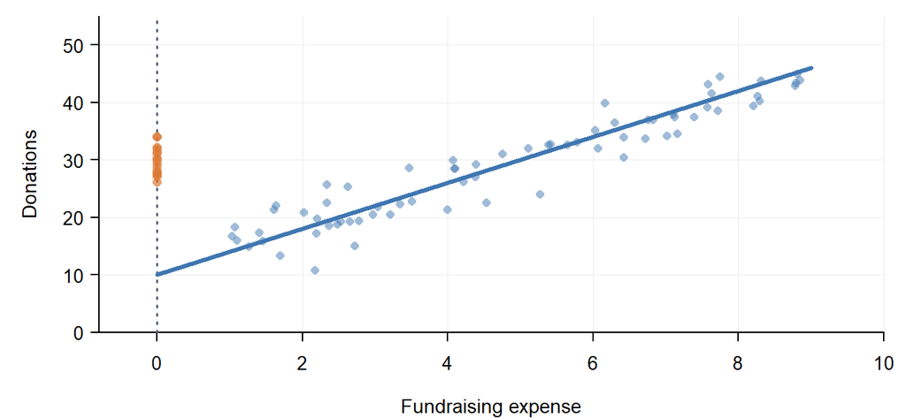

Short answer

Add *d*<sub>zero</sub> = I(*X* = 0): *Y* = *β*<sub>0</sub> + *β*<sub>1</sub>*X* + *β*<sub>2</sub>*d*<sub>zero</sub> + *ε* gives (10, 4, 20). *β*<sub>2</sub> compares the zero group’s mean (30) with the **positive-case line extrapolated to *X* = 0** (10). It is not a comparison with the average positive organization.

#### Why this works

- Zero cases (*X* = 0, *d*<sub>zero</sub> = 1): *Y* = *β*<sub>0</sub> + *β*<sub>2</sub> = 30
- Positive cases (*d*<sub>zero</sub> = 0): *Y* = *β*<sub>0</sub> + *β*<sub>1</sub>*X* = 10 + 4*X*

The zero group gets its own mean through *β*<sub>0</sub> + *β*<sub>2</sub>, so the line (*β*<sub>0</sub> and *β*<sub>1</sub>) is estimated from the positive cases alone. That is the second benefit of the dummy. Without it, the pile at 30 would drag the intercept up and flatten the slope, misdescribing the organizations that do fundraise. *β*<sub>2</sub> asks whether “zero” behaves like the smallest possible amount of fundraising, or like a different kind of organization. Here it is clearly the second: non-fundraisers raise far more than the line predicts.

#### Design matrix

| Observation type | *Y* | 1 | *X* | *d*<sub>zero</sub> | *d*<sub>positive</sub> |
| --- | --- | --- | --- | --- | --- |
| Zero expense | 30 | 1 | 0 | 1 | 0 |
| Positive, *X* = 2 | 18 | 1 | 2 | 0 | 1 |
| Positive, *X* = 5 | 30 | 1 | 5 | 0 | 1 |

#### Models

Zero indicator: *Y* = *β*<sub>0</sub> + *β*<sub>1</sub>*X* + *β*<sub>2</sub>*d*<sub>zero</sub> + *ε*

Positive indicator: *Y* = *γ*<sub>0</sub> + *γ*<sub>1</sub>*X* + *γ*<sub>2</sub>*d*<sub>positive</sub> + *ε*

| Coefficient | Value | Testing it equals zero asks… |
| --- | --- | --- |
| Zero indicator |  |  |
| *β*<sub>0</sub> | 10 | Is the positive-case line zero at *X* = 0? (descriptive only) |
| *β*<sub>1</sub> | 4 | Do donations rise with fundraising among positive cases? |
| *β*<sub>2</sub> | 20 | Do zero cases sit on the extrapolated line? |
| Positive indicator |  |  |
| *γ*<sub>0</sub> | 30 | Is the zero-group mean zero? (descriptive only) |
| *γ*<sub>1</sub> | 4 | Do donations rise with fundraising among positive cases? |
| *γ*<sub>2</sub> | −20 | Does the extrapolated line meet the zero-group mean at *X* = 0? |

Common mistakes

- **Putting I(*Y* = 0) on the right-hand side.** The pile-up is in *X*, not *Y*, and a predictor built from the outcome is never legitimate.
- **Reading *β*<sub>2</sub> as “zero cases versus the average positive case.”** It compares with the line at *X* = 0.
- **Adding *X*·*d*<sub>zero</sub> for a zero-group slope.** The column is always zero, since *X* = 0 whenever *d*<sub>zero</sub> = 1. A group with one *X* value has no slope.

← Back to question

### 11. Zero group and size-specific slopes

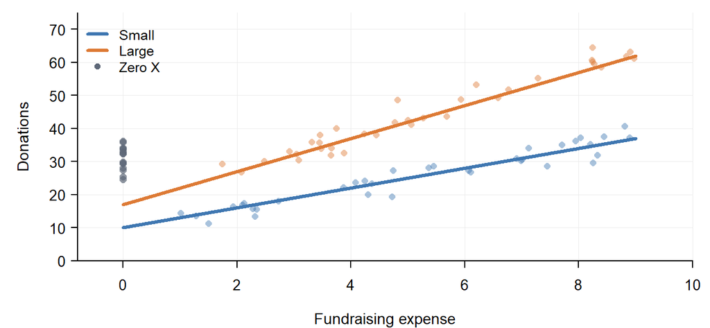

Short answer

With small positive-*X* organizations as the reference, *Y* = *β*<sub>0</sub> + *β*<sub>1</sub>*X* + *β*<sub>2</sub>*d*<sub>zero</sub> + *β*<sub>3</sub>*d*<sub>large</sub> + *β*<sub>4</sub>(*X**d*<sub>large</sub>) + *ε* gives (10, 3, 20, 7, 2). The three departures are *β*<sub>2</sub> (zero group), *β*<sub>3</sub> (large intercept), and *β*<sub>4</sub> (large slope). Code *d*<sub>large</sub> = 0 for every zero case, so the zero group is a third category rather than a subset of small or large.

#### Why this works

The model describes three groups, each with its own equation:

- Zero cases: *Y* = *β*<sub>0</sub> + *β*<sub>2</sub> = 30
- Small, positive: *Y* = *β*<sub>0</sub> + *β*<sub>1</sub>*X* = 10 + 3*X*
- Large, positive: *Y* = (*β*<sub>0</sub> + *β*<sub>3</sub>) + (*β*<sub>1</sub> + *β*<sub>4</sub>)*X* = 17 + 5*X*

This combines exercise 10 (a dummy for the pile at zero) with exercise 4 (intercept and slope shifts for a second group). The coding of size for zero cases matters. If a large zero-expense organization had *d*<sub>large</sub> = 1, its prediction would be *β*<sub>0</sub> + *β*<sub>2</sub> + *β*<sub>3</sub>. Then *β*<sub>3</sub> would have to describe both the gap between the positive lines *and* a size gap within the zero group, forcing the two to be equal.

If size genuinely matters among zero cases, code it for them and add *d*<sub>zero</sub>*d*<sub>large</sub>, so the zero group can have separate small and large means.

#### Design matrix

| Observation type | *Y* | 1 | *X* | *d*<sub>zero</sub> | *d*<sub>small</sub> | *d*<sub>large</sub> | *X**d*<sub>large</sub> |
| --- | --- | --- | --- | --- | --- | --- | --- |
| Zero *X* | 30 | 1 | 0 | 1 | 0 | 0 | 0 |
| Small, *X* = 2 | 16 | 1 | 2 | 0 | 1 | 0 | 0 |
| Small, *X* = 5 | 25 | 1 | 5 | 0 | 1 | 0 | 0 |
| Large, *X* = 2 | 27 | 1 | 2 | 0 | 0 | 1 | 2 |
| Large, *X* = 5 | 42 | 1 | 5 | 0 | 0 | 1 | 5 |

| Coefficient | Value | Testing it equals zero asks… |
| --- | --- | --- |
| Small-positive reference |  |  |
| *β*<sub>0</sub> | 10 | Is the small-positive line zero at *X* = 0? (descriptive only) |
| *β*<sub>1</sub> | 3 | Do donations rise with fundraising for small organizations? |
| *β*<sub>2</sub> | 20 | Do zero cases sit on the extrapolated small-organization line? |
| *β*<sub>3</sub> | 7 | Do large and small lines meet at *X* = 0? |
| *β*<sub>4</sub> | 2 | Do large and small organizations have the same slope? |

Common mistakes

- **Adding *X**d*<sub>zero</sub> to give the zero group a slope.** The column is all zeros.
- **Adding *d*<sub>small</sub> to the model.** *d*<sub>zero</sub>, *d*<sub>small</sub>, and *d*<sub>large</sub> cover every case exactly once, so all three plus the intercept are collinear.

← Back to question

### 12. A single outlying year

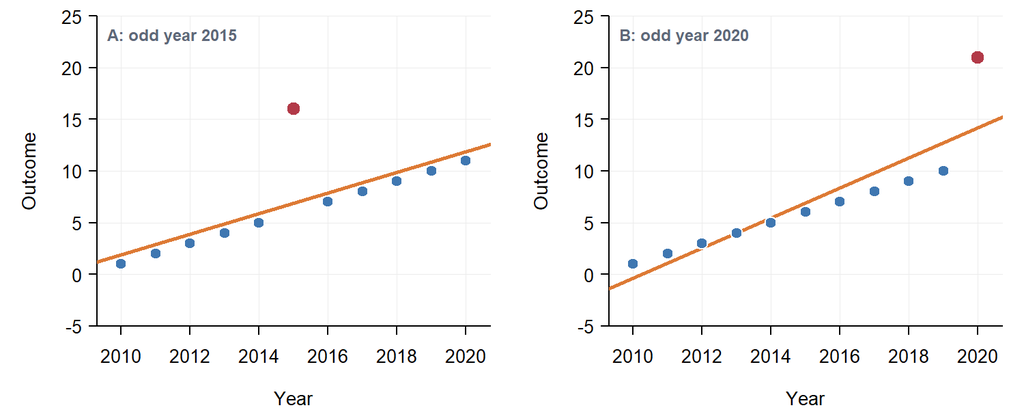

Short answer

Without a dummy, the middle-year outlier (A) lifts the whole line but leaves the slope at 1.00. The last-year outlier (B) tilts the line, raising the slope to 1.45. Add a dummy that equals 1 in the odd year only, *d*<sub>2015</sub> or *d*<sub>2020</sub>:

*Y* = *β*<sub>0</sub> + *β*<sub>1</sub>*t* + *δ**d*<sub>odd</sub> + *ε*

In both panels this gives *β*<sub>0</sub> = 0, *β*<sub>1</sub> = 1, *δ* = 10. The trend is estimated from the ten ordinary years, and *δ* is how far the odd year sits above that trend.

#### How one point moves a line

An outlier pulls on the fitted line in two ways. It always raises the mean of *Y*, and the line must pass through (*t̄*, *Ȳ*), so the whole line lifts. How much it also *tilts* the line depends on its distance from the middle of the *t* values, its **leverage**:

change in slope = 10 × (*t*<sub>odd</sub> − *t̄*) / Σ(*t* − *t̄*)<sup>2</sup> = 10 × (*t*<sub>odd</sub> − 6) / 110

- **Panel A, 2015** (*t* = 6 = *t̄*): no leverage, so the slope stays at 1.00. The intercept rises from 0 to 10/11 ≈ 0.91. The residuals balloon, so the slope’s standard error jumps from about 0 to 0.30.
- **Panel B, 2020** (*t* = 11): maximum leverage. The slope rises by 50/110 ≈ 0.45 to 1.45, and the intercept falls to −1.82 to compensate. An odd *first* year would do the opposite: slope 0.55, intercept 3.64.

So a single bad year at the end of a series can manufacture or hide a trend, which is exactly where policy series tend to have their surprises.

#### Why one dummy fixes it

A dummy that is 1 for a single observation gives that observation its own intercept. The model can then fit it exactly (*β*<sub>0</sub> + *β*<sub>1</sub>*t* + *δ* = *Y*), so it has no residual left to pull the line with. The trend is estimated from the other ten years alone. That gives the same slope and intercept as deleting the year, but the observation stays in the data and you get a coefficient for it.

*δ* is the gap between the odd year and the value the trend predicts for it: 16 − 6 = 10 in panel A and 21 − 11 = 10 in panel B. Its t-test is the standard regression test for an outlier: is this year further from the trend than ordinary noise would put it?

#### Design matrix

Each panel uses only its own dummy.

| Observation type | *Y* (A) | *Y* (B) | 1 | *t* | *d*<sub>2015</sub> | *d*<sub>2020</sub> |
| --- | --- | --- | --- | --- | --- | --- |
| 2010 | 1 | 1 | 1 | 1 | 0 | 0 |
| 2014 | 5 | 5 | 1 | 5 | 0 | 0 |
| 2015 | 16 | 6 | 1 | 6 | 1 | 0 |
| 2016 | 7 | 7 | 1 | 7 | 0 | 0 |
| 2019 | 10 | 10 | 1 | 10 | 0 | 0 |
| 2020 | 11 | 21 | 1 | 11 | 0 | 1 |

| Coefficient | Value | Testing it equals zero asks… |
| --- | --- | --- |
| No dummy · panel A / panel B |  |  |
| *β*<sub>0</sub> | 0.91 / −1.82 | Is the fitted line zero at *t* = 0? (descriptive only) |
| *β*<sub>1</sub> | 1.00 / 1.45 | Is there a trend? (A is right but noisy; B is biased by the endpoint) |
| With the odd-year dummy · both panels |  |  |
| *β*<sub>0</sub> | 0 | Is the trend zero at *t* = 0? (descriptive only) |
| *β*<sub>1</sub> | 1 | Is there a trend among the ordinary years? |
| *δ* | 10 | Does the odd year sit on the trend line? |

Common mistakes

- **Deleting the year without saying so.** The line is the same, but readers cannot see the decision and you lose the test of whether the year really was unusual.
- **Adding a dummy for every point that does not fit.** A dummy should have a reason that exists before you look at the residuals: a known strike, a coding change, a pandemic. Give enough points their own dummy and any line fits perfectly.
- **Reading the dummy’s p-value at face value after hunting for the biggest residual.** Picking the worst of eleven years and then testing it is eleven tests, not one. The multiple-comparison logic of the Bonferroni correction (Unit 09) applies.
- **Using a step dummy (1 from 2015 onward) for a one-year blip.** That models a permanent shift, not a single odd year.

← Back to question

### 13A. Flat before, flat after

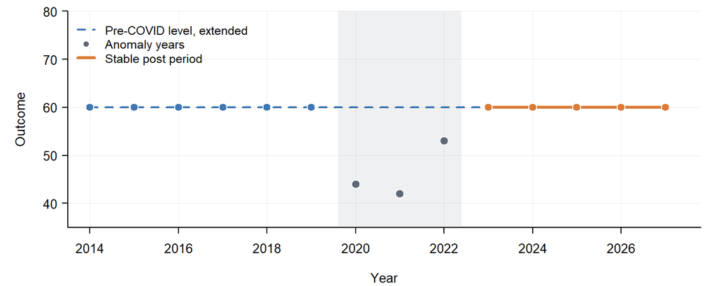

Short answer

Omit *d*<sub>pre</sub>:

*Y* = *β*<sub>0</sub> + *δ*<sub>20</sub>*d*<sub>covid20</sub> + *δ*<sub>21</sub>*d*<sub>covid21</sub> + *δ*<sub>22</sub>*d*<sub>covid22</sub> + *δ*<sub>P</sub>*d*<sub>post</sub> + *ε*

This gives *β*<sub>0</sub> = 60, anomaly deviations (−16, −18, −7), and *δ*<sub>P</sub> = 0: the outcome went back to exactly where it was. If the COVID years are left in the reference group, the same data show a spurious post-COVID *gain* of about 4.6.

#### Why this works

This is exercise 12 three times over. Each anomaly year has its own dummy, so each is fit exactly and cannot contaminate either the pre or the post level. With no trend in the model, every coefficient is a plain difference in means from the pre-COVID years:

- Pre years: *β*<sub>0</sub> = 60
- 2020: 60 + *δ*<sub>20</sub> = 44 → *δ*<sub>20</sub> = −16; 2021: *δ*<sub>21</sub> = −18; 2022: *δ*<sub>22</sub> = −7
- Post years: 60 + *δ*<sub>P</sub> = 60 → *δ*<sub>P</sub> = 0

Because nothing else changes over time, *δ*<sub>P</sub> here *is* the raw difference between the post and pre means, and that is the right contrast. Keep this in mind for 13B, where adding a trend breaks that equivalence.

Two separate questions, two separate tests. Was there a temporary disruption? Test *δ*<sub>20</sub> = *δ*<sub>21</sub> = *δ*<sub>22</sub> = 0 jointly. Is there a lasting change? Test *δ*<sub>P</sub> = 0. Here the answers are yes and no.

#### What goes wrong without the COVID dummies

The anomaly years have to go *somewhere*. If you code only *d*<sub>post</sub>, they join whichever group is left:

| COVID years placed in… | *δ*<sub>P</sub> | What the model concludes |
| --- | --- | --- |
| their own dummies | 0 | No lasting change. Correct. |
| the reference (pre) group | +4.6 | The pre mean drops to (6·60 + 44 + 42 + 53)/9 ≈ 55.4, so post looks like a gain. |
| the post group | −5.1 | The post mean drops to (44 + 42 + 53 + 5·60)/8 ≈ 54.9, so post looks like a loss. |

The same three odd years produce a gain, a loss, or nothing, depending only on where they are filed. That is exercise 12’s lesson about a single outlier, in dummy-variable form.

#### Design matrix

| Observation type | *Y* | 1 | *d*<sub>pre</sub> | *d*<sub>covid20</sub> | *d*<sub>covid21</sub> | *d*<sub>covid22</sub> | *d*<sub>post</sub> |
| --- | --- | --- | --- | --- | --- | --- | --- |
| Pre, 2014 | 60 | 1 | 1 | 0 | 0 | 0 | 0 |
| Pre, 2019 | 60 | 1 | 1 | 0 | 0 | 0 | 0 |
| COVID, 2020 | 44 | 1 | 0 | 1 | 0 | 0 | 0 |
| COVID, 2021 | 42 | 1 | 0 | 0 | 1 | 0 | 0 |
| COVID, 2022 | 53 | 1 | 0 | 0 | 0 | 1 | 0 |
| Post, 2023 | 60 | 1 | 0 | 0 | 0 | 0 | 1 |
| Post, 2027 | 60 | 1 | 0 | 0 | 0 | 0 | 1 |

In the shorthand *d*<sub>0</sub>, …, *d*<sub>4</sub>, these five indicators are *d*<sub>pre</sub>, *d*<sub>covid20</sub>, *d*<sub>covid21</sub>, *d*<sub>covid22</sub>, *d*<sub>post</sub> in that order.

| Coefficient | Value | Testing it equals zero asks… |
| --- | --- | --- |
| Pre-COVID reference |  |  |
| *β*<sub>0</sub> | 60 | Is the pre-COVID level zero? (descriptive only) |
| *δ*<sub>20</sub> | −16 | Was 2020 at the pre-COVID level? |
| *δ*<sub>21</sub> | −18 | Was 2021 at the pre-COVID level? |
| *δ*<sub>22</sub> | −7 | Was 2022 at the pre-COVID level? |
| *δ*<sub>P</sub> | 0 | Is the post-COVID level different from the pre-COVID level? |

Common mistakes

- **Coding only *d*<sub>post</sub>.** The COVID years land in one of the comparison groups and create a shift that is not there (table above).
- **Using one *d*<sub>covid</sub> dummy for all three years.** That protects the pre and post levels, but forces 2020–2022 to share one mean and hides the recovery path (−16, −18, −7).
- **Including all five period dummies with the intercept.** They sum to one on every row.

← Back to question

### 13B. Add a trend

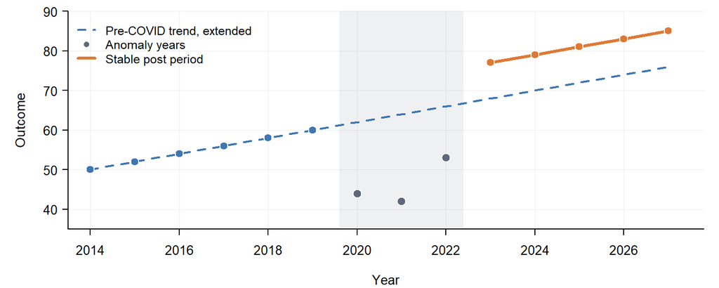

Short answer

Keep the 13A dummies, still omitting *d*<sub>pre</sub>, and add a calendar trend *t* = year − 2014:

*Y* = *β*<sub>0</sub> + *β*<sub>1</sub>*t* + *δ*<sub>20</sub>*d*<sub>covid20</sub> + *δ*<sub>21</sub>*d*<sub>covid21</sub> + *δ*<sub>22</sub>*d*<sub>covid22</sub> + *δ*<sub>P</sub>*d*<sub>post</sub> + *ε*

This gives a trend of 50 + 2*t*, anomaly deviations (−18, −22, −13), and *δ*<sub>P</sub> = 9. **No**, unlike 13A, *δ*<sub>P</sub> is no longer the raw difference in period means. That raw difference is 26, and 17 of it is just the old trend continuing.

#### Why this works

Because the trend term is in the model, every dummy coefficient is a *vertical* distance from the pre-COVID trend line, measured in the same year. Omitting *d*<sub>pre</sub> makes the ordinary pre years the reference, so the trend line is estimated from them. In 13A the reference line was flat, so “distance from the line” and “difference in means” were the same thing. Here they are not.

- **Each anomaly year gets its own dummy.** As in exercise 12, one dummy for a single year fits that year exactly, so the three unusual points cannot pull the trend line around. Each *δ* is that year’s deviation from where the trend would have put it. For 2020, the trend predicts 50 + 2·6 = 62 and the observed value is 44, so *δ*<sub>20</sub> = −18.
- *δ*<sub>P</sub> is a shift, not a change in means. In 2023 the trend predicts 50 + 2·9 = 68 and the observed value is 77, a gap of 9. Because the post line is parallel, the gap is 9 in every post year.

Compare that with the naive comparison. The post-period mean (2023–2027) is 81 and the pre-period mean (2014–2019) is 55, a difference of 26. But the trend alone would have raised the mean from 55 to 72 across those years (+17). Only the remaining 9 is a new level.

To test for a temporary disruption, test the three anomaly coefficients *jointly*: *δ*<sub>20</sub> = *δ*<sub>21</sub> = *δ*<sub>22</sub> = 0 (an F-test). To test for a lasting shift, test *δ*<sub>P</sub> = 0.

#### Design matrix

| Observation type | *Y* | 1 | *t* | *d*<sub>pre</sub> | *d*<sub>covid20</sub> | *d*<sub>covid21</sub> | *d*<sub>covid22</sub> | *d*<sub>post</sub> |
| --- | --- | --- | --- | --- | --- | --- | --- | --- |
| Pre, 2014 | 50 | 1 | 0 | 1 | 0 | 0 | 0 | 0 |
| Pre, 2019 | 60 | 1 | 5 | 1 | 0 | 0 | 0 | 0 |
| COVID, 2020 | 44 | 1 | 6 | 0 | 1 | 0 | 0 | 0 |
| COVID, 2021 | 42 | 1 | 7 | 0 | 0 | 1 | 0 | 0 |
| COVID, 2022 | 53 | 1 | 8 | 0 | 0 | 0 | 1 | 0 |
| Post, 2023 | 77 | 1 | 9 | 0 | 0 | 0 | 0 | 1 |
| Post, 2025 | 81 | 1 | 11 | 0 | 0 | 0 | 0 | 1 |

In the shorthand *d*<sub>0</sub>, …, *d*<sub>4</sub>, these five indicators are *d*<sub>pre</sub>, *d*<sub>covid20</sub>, *d*<sub>covid21</sub>, *d*<sub>covid22</sub>, *d*<sub>post</sub> in that order.

| Coefficient | Value | Testing it equals zero asks… |
| --- | --- | --- |
| Pre-COVID reference |  |  |
| *β*<sub>0</sub> | 50 | Is the trend level in 2014 zero? (descriptive only) |
| *β*<sub>1</sub> | 2 | Was there a pre-COVID trend? |
| *δ*<sub>20</sub> | −18 | Was 2020 on the extrapolated trend? |
| *δ*<sub>21</sub> | −22 | Was 2021 on the extrapolated trend? |
| *δ*<sub>22</sub> | −13 | Was 2022 on the extrapolated trend? |
| *δ*<sub>P</sub> | 9 | Is the stable post period on the extrapolated trend, compared in the same year? |

Common mistakes

- **Regressing on 1 and *d*<sub>post</sub> alone.** This compares raw means from different years (26) and credits the ordinary trend to the new regime.
- **Including all five period dummies with the intercept.** They sum to one on every row.
- **Reading *δ*<sub>P</sub> as the effect of COVID.** It shows that the level shifted around 2023. Attributing the shift to COVID needs a design argument (a comparison series, a mechanism), not just the coefficient.

← Back to question

### 13C. What if the post-COVID slope changed?

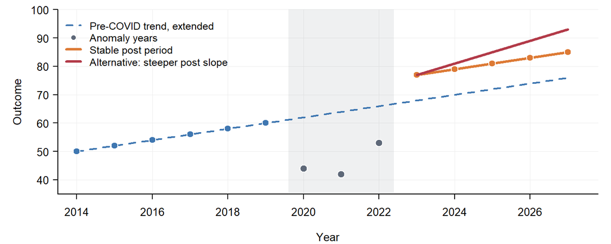

Short answer

Keep the model from 13B and add *t*<sub>post</sub> = (year − 2023)·*d*<sub>post</sub>, which is zero before 2023 *and* in 2023 itself. Its coefficient *θ* = 2 tests the slope change, *δ*<sub>P</sub> = 9 is still the jump in 2023, and the post slope is *β*<sub>1</sub> + *θ* = 4.

#### Why this works

This is the interrupted time series of exercise 8 on top of the anomaly dummies of exercise 13B. The post line is

*Y* = *β*<sub>0</sub> + *β*<sub>1</sub>*t* + *δ*<sub>P</sub> + *θ*(year − 2023)

In 2023 the last term vanishes, so the gap from the pretrend there is exactly *δ*<sub>P</sub>. Each later year adds *θ* to the gap. Starting the post clock at 2023 is what keeps *δ*<sub>P</sub> meaning “the jump at the start of the new regime.”

Suppose you used *t*·*d*<sub>post</sub> instead, with *t* counted from 2014. The post line would then be (*β*<sub>0</sub> + *δ*<sub>P</sub>) + (*β*<sub>1</sub> + *θ*)*t*, so *δ*<sub>P</sub> would be the gap extrapolated back to 2014: 9 − 9·2 = −9. The fit is identical, but the sign of the headline coefficient flips.

Test the two components separately, or test *δ*<sub>P</sub> = *θ* = 0 jointly to ask whether the post regime differs from the old trend in any way.

#### Design matrix

| Observation type | *Y* | 1 | *t* | *d*<sub>pre</sub> | *d*<sub>covid20</sub> | *d*<sub>covid21</sub> | *d*<sub>covid22</sub> | *d*<sub>post</sub> | *t*<sub>post</sub> |
| --- | --- | --- | --- | --- | --- | --- | --- | --- | --- |
| Pre, 2014 | 50 | 1 | 0 | 1 | 0 | 0 | 0 | 0 | 0 |
| Pre, 2019 | 60 | 1 | 5 | 1 | 0 | 0 | 0 | 0 | 0 |
| COVID, 2020 | 44 | 1 | 6 | 0 | 1 | 0 | 0 | 0 | 0 |
| COVID, 2021 | 42 | 1 | 7 | 0 | 0 | 1 | 0 | 0 | 0 |
| COVID, 2022 | 53 | 1 | 8 | 0 | 0 | 0 | 1 | 0 | 0 |
| Post, 2023 | 77 | 1 | 9 | 0 | 0 | 0 | 0 | 1 | 0 |
| Post, 2025 | 85 | 1 | 11 | 0 | 0 | 0 | 0 | 1 | 2 |
| Post, 2027 | 93 | 1 | 13 | 0 | 0 | 0 | 0 | 1 | 4 |

| Coefficient | Value | Testing it equals zero asks… |
| --- | --- | --- |
| Pre-COVID reference |  |  |
| *β*<sub>0</sub> | 50 | Is the trend level in 2014 zero? (descriptive only) |
| *β*<sub>1</sub> | 2 | Was there a pre-COVID trend? |
| *δ*<sub>20</sub>, *δ*<sub>21</sub>, *δ*<sub>22</sub> | −18, −22, −13 | Was each anomaly year on the extrapolated trend? |
| *δ*<sub>P</sub> | 9 | Was 2023 on the extrapolated trend? |
| *θ* | 2 | Is the post slope the same as the pre slope? |

Common mistakes

- **Inferring a slope change from *d*<sub>post</sub> alone.** That term shifts the level only.
- **Using raw year × *d*<sub>post</sub> and reading *δ*<sub>P</sub> as the gap in 2023.** As shown above, it becomes a gap extrapolated to year zero of whatever clock you used. Center the post clock at 2023.

← Back to question

### 14. Reverse-engineer the coding

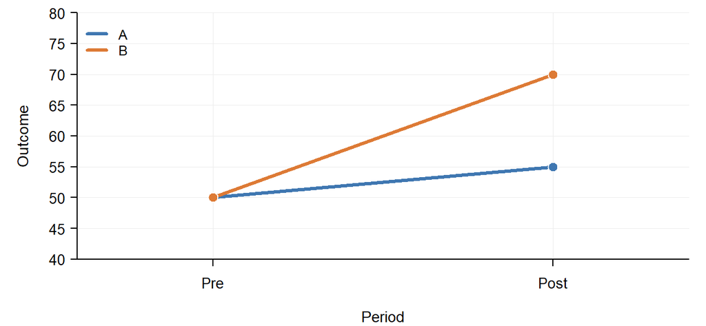

Short answer

- **(a)** Reference A/pre: the *d*<sub>B</sub> coefficient, *β*<sub>1</sub> = 0.
- **(b)** Reference A/post: the *d*<sub>B</sub> coefficient, *γ*<sub>1</sub> = 15.
- **(c)** Reference B/pre: the *d*<sub>post</sub> coefficient, *λ*<sub>2</sub> = 20.
- **(d)** Any reference: the interaction, ±15.

None of the four is impossible. What *is* impossible is getting all four from one model, or getting a diagonal contrast (such as B/post versus A/pre) as a single coefficient under any coding.

#### Why this works

A saturated 2 × 2 model has an intercept and three coefficients, and every one of them is anchored at the reference cell:

- the **group** main effect compares the two groups *in the reference period*;
- the **period** main effect is the change over time *for the reference group*;
- the **interaction** is the difference in changes, which is the same contrast from every reference, up to sign.

So to test a group gap in a particular period, make that period the reference. To test one group’s change, make that group the reference. The diagonal contrast from the reference cell is always the sum of all three coefficients (for example, B/post versus A/pre is *β*<sub>1</sub> + *β*<sub>2</sub> + *β*<sub>3</sub> = 20 in Model 1). No choice of reference makes it a single coefficient, so it needs a linear-combination test.

#### Design matrix

Choose one group indicator and one period indicator for each model. Each interaction column is the product of the two indicators you chose.

| Observation type | *Y* | 1 | *d*<sub>A</sub> | *d*<sub>B</sub> | *d*<sub>pre</sub> | *d*<sub>post</sub> | *d*<sub>B</sub>*d*<sub>post</sub> | *d*<sub>B</sub>*d*<sub>pre</sub> | *d*<sub>A</sub>*d*<sub>post</sub> |
| --- | --- | --- | --- | --- | --- | --- | --- | --- | --- |
| A, pre | 50 | 1 | 1 | 0 | 1 | 0 | 0 | 0 | 0 |
| B, pre | 50 | 1 | 0 | 1 | 1 | 0 | 0 | 1 | 0 |
| A, post | 55 | 1 | 1 | 0 | 0 | 1 | 0 | 0 | 1 |
| B, post | 70 | 1 | 0 | 1 | 0 | 1 | 1 | 0 | 0 |

#### Models

The models are numbered rather than lettered, so they are not confused with groups A and B.

Model 1 (A/pre): *Y* = *β*<sub>0</sub> + *β*<sub>1</sub>*d*<sub>B</sub> + *β*<sub>2</sub>*d*<sub>post</sub> + *β*<sub>3</sub>(*d*<sub>B</sub>*d*<sub>post</sub>) + *ε*

Model 2 (A/post): *Y* = *γ*<sub>0</sub> + *γ*<sub>1</sub>*d*<sub>B</sub> + *γ*<sub>2</sub>*d*<sub>pre</sub> + *γ*<sub>3</sub>(*d*<sub>B</sub>*d*<sub>pre</sub>) + *ε*

Model 3 (B/pre): *Y* = *λ*<sub>0</sub> + *λ*<sub>1</sub>*d*<sub>A</sub> + *λ*<sub>2</sub>*d*<sub>post</sub> + *λ*<sub>3</sub>(*d*<sub>A</sub>*d*<sub>post</sub>) + *ε*

| Coefficient | Value | Testing it equals zero asks… |
| --- | --- | --- |
| Model 1 · A/pre reference |  |  |
| *β*<sub>0</sub> | 50 | Is the A pre mean zero? (descriptive only) |
| *β*<sub>1</sub> | 0 | **(a)** Are B and A equal in the pre period? |
| *β*<sub>2</sub> | 5 | Did A change from pre to post? |
| *β*<sub>3</sub> | 15 | **(d)** Did B and A change by the same amount? |
| Model 2 · A/post reference |  |  |
| *γ*<sub>0</sub> | 55 | Is the A post mean zero? (descriptive only) |
| *γ*<sub>1</sub> | 15 | **(b)** Are B and A equal in the post period? |
| *γ*<sub>2</sub> | −5 | Are A’s pre and post means equal? |
| *γ*<sub>3</sub> | −15 | **(d)** Is the B−A gap the same pre and post? |
| Model 3 · B/pre reference |  |  |
| *λ*<sub>0</sub> | 50 | Is the B pre mean zero? (descriptive only) |
| *λ*<sub>1</sub> | 0 | Are A and B equal in the pre period? |
| *λ*<sub>2</sub> | 20 | **(c)** Did B change from pre to post? |
| *λ*<sub>3</sub> | −15 | **(d)** Did A and B change by the same amount? |

Common mistakes

- **Keeping A/pre as the reference and calling *β*<sub>1</sub> the post-period gap, or *β*<sub>2</sub> B’s change.** They are the pre-period gap and A’s change. For the others, switch the reference or test a sum (*β*<sub>1</sub> + *β*<sub>3</sub>, *β*<sub>2</sub> + *β*<sub>3</sub>).
- **Calling the interaction “B’s change.”** It is the *difference* between B’s change and A’s.

← Back to question

Section four

## Quick synthesis

Every exercise is the same move: choose the reference and the zero point so the contrast you want lands on one coefficient.

| Contrast in the picture | Coding choice | Coefficient or restriction |
| --- | --- | --- |
| Sample mean versus a benchmark | Center the outcome at the benchmark | Intercept = 0 |
| Group versus reference group | Omit the comparison group | Group dummy = 0 |
| Same people before and after | Person intercepts, or difference scores | Post dummy = 0 |
| Difference in slopes | Interact the group dummy with *X* | Interaction = 0 |
| Effect in one particular setting | Make that setting the reference | Program main effect = 0 |
| Difference in changes | Group × post | Interaction = 0 |
| Increment from one more dose | Cumulative “at least *k*” dummies | Dose-*k* dummy = 0 |
| Immediate jump at a date or cutoff | Center the running variable there | Post / threshold dummy = 0 |
| Slope change at an interruption date | Centered time × post dummy | Interaction = 0 |
| One outlying observation | A dummy equal to 1 for that observation only | That dummy = 0 (an outlier test) |
| Temporary anomalous periods | One indicator per anomalous period | Joint F-test of those dummies |
| New regime after anomalies | Pre regime omitted, calendar trend included | Post dummy = 0, at a common time |
| Distinct group at predictor zero | I(*X* = 0) | Zero dummy = 0, versus the extrapolated line |

### What should be clear in my mind?

1. **Name the reference before reading any coefficient.** Every dummy coefficient is a gap from the omitted category.
2. **Know where each gap is measured.** In a model with an interaction, a dummy coefficient is the gap where the continuous variable equals zero. Center to move that point where you want it.
3. **Recover any cell or line by adding coefficients.** Write the equation for each row of the design matrix and solve from the reference outward.
4. **Distinguish imposing from testing.** Leaving out an interaction *assumes* parallel lines; including it lets you test them.
5. **When a contrast is a sum of coefficients**, either recode so it becomes one coefficient, or run a linear-combination test.
6. **Never enter a complete set of complementary indicators alongside an intercept.**

Instructor note

The diagrams deliberately show conditional means without sampling uncertainty. Have students write the estimand and the model first, then give them an actual dataset to fit the model with standard errors appropriate to its design (clustered for repeated measures, robust for unequal variances, and so on).